# IODS course project

Maija Nuppunen-Puputti

# About the IODS project

*I heard about this course in the MBDP Metagenomics course last spring. I wish to develop my **R** skills further and learn more about **RMarkdown**, version control and using **GitHub**.*

1 [**Link to my GitHub repository**](https://github.com/mnpuputti/IODS-project)

2 or: https://github.com/mnpuputti/IODS-project

# IODS week 2. Regression and model validation: Data analysis

*This week we practised data wrangling and data visualization for linear models in DataCamp with packages **dplyr and ggplot2**. We practised making scripts for data wrangling in R with **“Learning2014”** dataset. We used this dataset, modifed the data to match IODS-course needs, and we will call that part of the dataset **“Students2014”**. Dataset is available [**here.**](http://www.helsinki.fi/~kvehkala/JYTmooc/JYTOPKYS3-data.txt)*

### Bringing data into R

*Explore the **“Students2014”** dataset. This dataset contains part of the “the international survey of Approaches to Learning”*

```r
#Read data "students2014" into R from .csv-file created in the data wrangling part of week2.
students2014 <- read.csv("~/Documents/MAIJA/R_IODS/IODS-project/data/learning2014.csv", row.names = 1)
```

```r
#Check dimensions and structure of the dataset.
dim(students2014)
```

```
## [1] 166   7
```

```r
str(students2014)
```

```
## 'data.frame':    166 obs. of  7 variables:
##  $ gender  : Factor w/ 2 levels "F","M": 1 2 1 2 2 1 2 1 2 1 ...
##  $ age     : int  53 55 49 53 49 38 50 37 37 42 ...
##  $ attitude: int  37 31 25 35 37 38 35 29 38 21 ...
##  $ deep    : num  3.58 2.92 3.5 3.5 3.67 ...
##  $ stra    : num  3.38 2.75 3.62 3.12 3.62 ...
##  $ surf    : num  2.58 3.17 2.25 2.25 2.83 ...
##  $ points  : int  25 12 24 10 22 21 21 31 24 26 ...
```

*There are 166 observations and seven different variables including: gender, age, attitude, deep, stra, surf and points. There are three different types of learning technique questions:* **“deep” = deep learning**,**“stra” = strategic learning** *and* **“surf” = surface learning**. *In addition there were categories for global attitude towards statistics* **“attitude”** *, exam points* **“points”** *and also the* **“gender”** *of the survey participants.*

Load the libraries needed in data visualization

```r
library(ggplot2)
library(dplyr)
library(GGally)
```

Check the data through visualizations

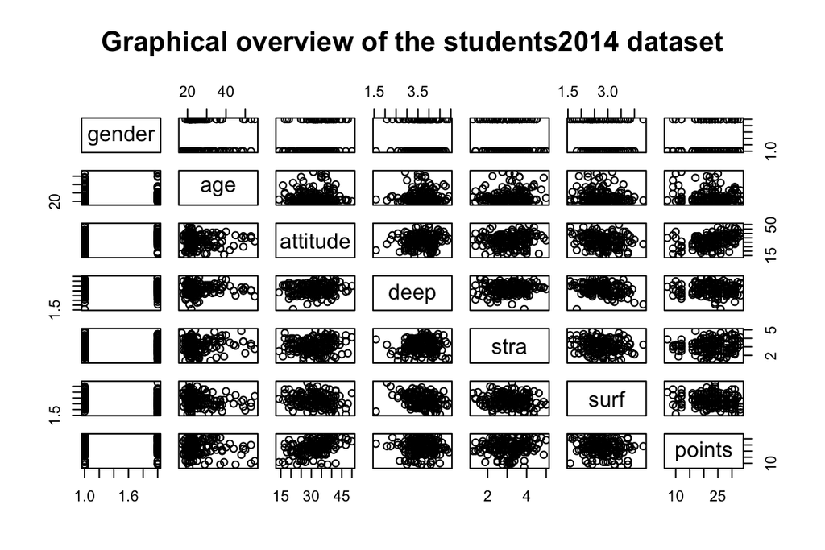

```r
###Check graphical overview with basic plot of pairwise correlations
p1 <- plot(students2014, main = "Graphical overview of the students2014 dataset")
```

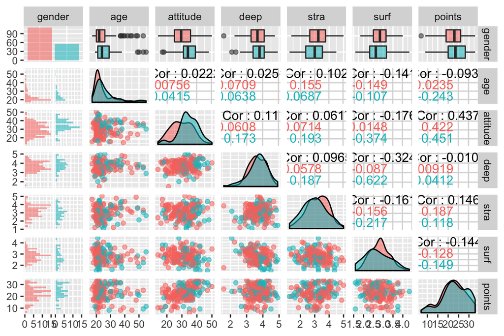

```r
##Check graphical overview with finer, more informative visual presentation of pairwise correlation plot, with ggpairs
ggpairs(students2014, mapping = aes(col = gender, alpha=0.3), lower = list(combo = wrap("facethist", bins = 20)))
```

### Summaries of the variables

```r
###Check summaries of the different variables available
summary(students2014)
```

```
##  gender       age           attitude          deep            stra
##  F:110   Min.   :17.00   Min.   :14.00   Min.   :1.583   Min.   :1.250
##  M: 56   1st Qu.:21.00   1st Qu.:26.00   1st Qu.:3.333   1st Qu.:2.625
##          Median :22.00   Median :32.00   Median :3.667   Median :3.188
##          Mean   :25.51   Mean   :31.43   Mean   :3.680   Mean   :3.121
##          3rd Qu.:27.00   3rd Qu.:37.00   3rd Qu.:4.083   3rd Qu.:3.625
##          Max.   :55.00   Max.   :50.00   Max.   :4.917   Max.   :5.000
##       surf           points
##  Min.   :1.583   Min.   : 7.00
##  1st Qu.:2.417   1st Qu.:19.00
##  Median :2.833   Median :23.00
##  Mean   :2.787   Mean   :22.72
##  3rd Qu.:3.167   3rd Qu.:27.75
##  Max.   :4.333   Max.   :33.00
```

```r
#or summaries could be also individually picked e.g.
summary(students2014$gender)
```

```
##   F   M
## 110  56
```

*From* *the graphical overview and summary we can see that there are more female participants in the gender category.* *Female participants are younger than male participants.* *Exam point means are on the similar level for both male and female participants. Male participants score better for the attitude points.* *There are no major correlations between any categories for either female or male participants.*  
*Highest* *correlation with the “point” variable is observed with the variable “attitude” and “stra” and negative correlation* *with “surf” variable“.* *The mean age is 25.51 with range from 17.00 to 55.00 years. The mean observed exam points is 22.72 with* *minimum being 7.00 and maximum points being 33.00. Deep learning mean is 3.68, strategic learning mean is 3.121 and surface learning techniques mean is 2.787.*

### Regression model

```r
#Create a regression model with three explanatory variables identified from pairwise correlation plot:stra + age + attitude,
model1 <- lm(points ~ stra + age + attitude, data = students2014)

#Check the summary of the regression model and plot the results
set.seed(123)
summary(model1)
```

```
##
## Call:
## lm(formula = points ~ stra + age + attitude, data = students2014)
##
## Residuals:
##      Min       1Q   Median       3Q      Max
## -18.1149  -3.2003   0.3303   3.4129  10.7599
##
## Coefficients:
##             Estimate Std. Error t value Pr(>|t|)
## (Intercept) 10.89543    2.64834   4.114 6.17e-05 ***
## stra         1.00371    0.53434   1.878   0.0621 .
## age         -0.08822    0.05302  -1.664   0.0981 .
## attitude     0.34808    0.05622   6.191 4.72e-09 ***
## ---
## Signif. codes:  0 '***' 0.001 '**' 0.01 '*' 0.05 '.' 0.1 ' ' 1
##
## Residual standard error: 5.26 on 162 degrees of freedom
## Multiple R-squared:  0.2182, Adjusted R-squared:  0.2037
## F-statistic: 15.07 on 3 and 162 DF,  p-value: 1.07e-08
```

*Summary shows that only “attitude” of the tested explanatory variables could be considered statistically significant based on the p-values. Attitude has the most significant impact on the points with positive p.value 4.72e-09, while stra is showing p-value 0.0621 and age 0.0981. Attitude shows estimate of 0.34, while estimate for stra is 1.0. For age variable the estimate is negative. We can continue with the “attitude” variable and re-fit the model without the non-significant variables.*

```r
#Re-fit the model with significant variable "attitude"
model2 <- lm(points ~ attitude, data = students2014)

#Check the summary of the regression model and plot the results
set.seed(123)
summary(model2)
```

```
##
## Call:
## lm(formula = points ~ attitude, data = students2014)
##
## Residuals:
##      Min       1Q   Median       3Q      Max
## -16.9763  -3.2119   0.4339   4.1534  10.6645
##
## Coefficients:
##             Estimate Std. Error t value Pr(>|t|)
## (Intercept) 11.63715    1.83035   6.358 1.95e-09 ***
## attitude     0.35255    0.05674   6.214 4.12e-09 ***
## ---
## Signif. codes:  0 '***' 0.001 '**' 0.01 '*' 0.05 '.' 0.1 ' ' 1
##
## Residual standard error: 5.32 on 164 degrees of freedom
## Multiple R-squared:  0.1906, Adjusted R-squared:  0.1856
## F-statistic: 38.61 on 1 and 164 DF,  p-value: 4.119e-09
```

*Now we can evaluate, whether the model and the data fit.* *The R-squared values tell us how close to the fitted (multiple) regression line our data is located. Multiple R-squared is 0.1906. This means that our model explains ~ 19 % of the variability around its mean.* *Estimates* *for the parametre for the model is 0.35255 for the attitude with standard error of 0.05674.*

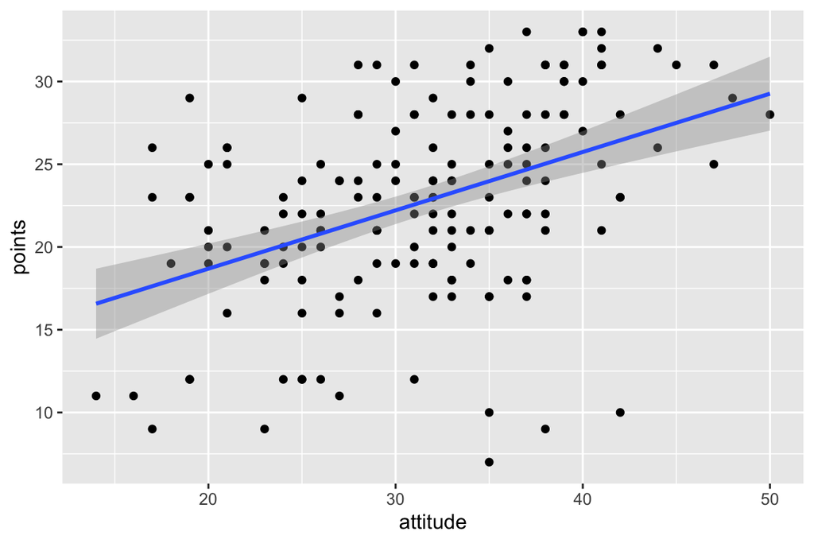

```r
#Check how does the model looks with "points and "attitude"
qplot(attitude, points, data = students2014) + geom_smooth(method = "lm")
```

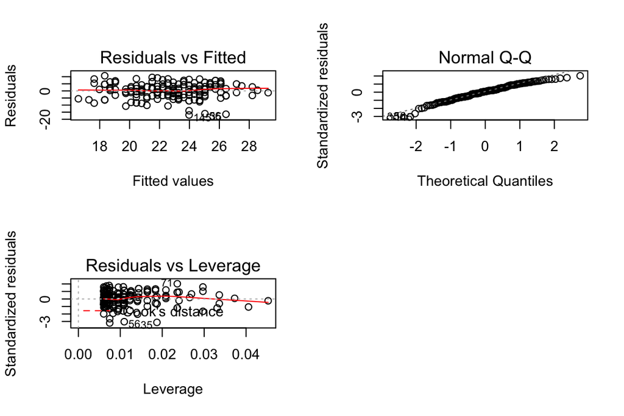

```r
#Draw and explore the diagnostic plots
par(mfrow = c(2,2))
plot(model2, which = c(1,2,5))
```

*Residuals are the errors in modelling the target variable. We want to minimize the modelling errors.* *Residuals vs fitted plot*: *There cannot be detected major spreading of the values. However, few outliers can be detected when fitted values increase.* *Normal QQ-plot* *explores the normal distribution potential of the errors. The data fits the normal distribution reasonably well, except the few outliers at the lower quantiles. We can say that the errors are normally distributed in this model.* *Residuals vs Leverage plot* *shows that there are no clear individual values that impact the model.*

# IODS Week 3: Logistic regression

*This dataset contain data on student achievements in two Portuguese schools. We look at how alcohol consumption habits effects student performance.*

*Dataset student.zip-file can be found [*here.*](https://archive.ics.uci.edu/ml/machine-learning-databases/00320/)* and information on dataset background [*here.*](https://archive.ics.uci.edu/ml/datasets/Student+Performance)

Let’s load needed libraries

```r
library(dplyr)
library(ggplot2)
library(tidyr)
```

### Reading in the data

Let’s read in the data from our data wrangling part. Alternatively, the modified dataset can be downloaded from [here](http://s3.amazonaws.com/assets.datacamp.com/production/course_2218/datasets/alc.txt)

```r
alc <- read.csv("~/Documents/MAIJA/R_IODS/IODS-project/data/alc.csv", row.names = 1)

#Let's check the variables:
names(alc)
```

```
##  [1] "school"     "sex"        "age"        "address"    "famsize"
##  [6] "Pstatus"    "Medu"       "Fedu"       "Mjob"       "Fjob"
## [11] "reason"     "nursery"    "internet"   "guardian"   "traveltime"
## [16] "studytime"  "failures"   "schoolsup"  "famsup"     "paid"
## [21] "activities" "higher"     "romantic"   "famrel"     "freetime"
## [26] "goout"      "Dalc"       "Walc"       "health"     "absences"
## [31] "G1"         "G2"         "G3"         "alc_use"    "high_use"
```

```r
#or use glimpse
glimpse(alc)
```

```
## Observations: 382
## Variables: 35
## $ school     <fct> GP, GP, GP, GP, GP, GP, GP, GP, GP, GP, GP, GP, GP, G…
## $ sex        <fct> F, F, F, F, F, M, M, F, M, M, F, F, M, M, M, F, F, F,…
## $ age        <int> 18, 17, 15, 15, 16, 16, 16, 17, 15, 15, 15, 15, 15, 1…
## $ address    <fct> U, U, U, U, U, U, U, U, U, U, U, U, U, U, U, U, U, U,…
## $ famsize    <fct> GT3, GT3, LE3, GT3, GT3, LE3, LE3, GT3, LE3, GT3, GT3…
## $ Pstatus    <fct> A, T, T, T, T, T, T, A, A, T, T, T, T, T, A, T, T, T,…
## $ Medu       <int> 4, 1, 1, 4, 3, 4, 2, 4, 3, 3, 4, 2, 4, 4, 2, 4, 4, 3,…
## $ Fedu       <int> 4, 1, 1, 2, 3, 3, 2, 4, 2, 4, 4, 1, 4, 3, 2, 4, 4, 3,…
## $ Mjob       <fct> at_home, at_home, at_home, health, other, services, o…
## $ Fjob       <fct> teacher, other, other, services, other, other, other,…
## $ reason     <fct> course, course, other, home, home, reputation, home, …
## $ nursery    <fct> yes, no, yes, yes, yes, yes, yes, yes, yes, yes, yes,…
## $ internet   <fct> no, yes, yes, yes, no, yes, yes, no, yes, yes, yes, y…
```

[output cut: 22 more lines]

*These parametres are fully explained at the data repository [site](https://archive.ics.uci.edu/ml/datasets/student+performance). Key variables explained shortly: **Dalc** describes workday alcohol consumption, **Walc** weekend alcohol consumption, **alc_use** describes average alcohol use per day. All these three parametres have scale from 1 (very low) to 5 (very high use). **High_use** describes whether student uses alcohol more than twice a week.*

Let’s see how the data looks in order to pick 4 interesting variables:

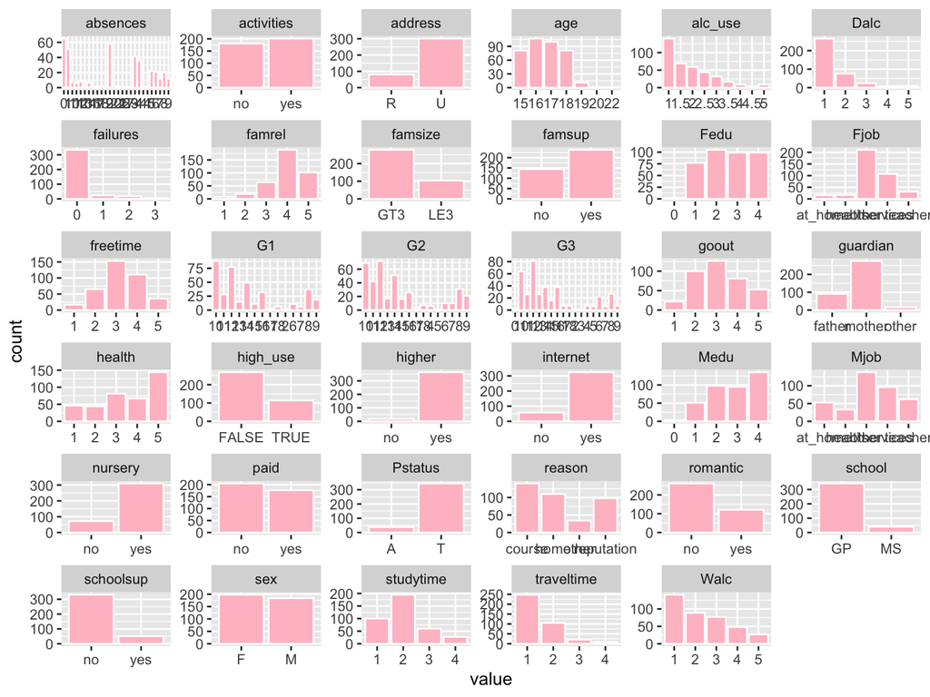

```r
# draw a bar plot of each variable
gather(alc) %>% ggplot(aes(value)) + geom_bar(color="white",fill="pink") + facet_wrap("key", scales = "free")
```

*Let’s pick variables:* **absences, school, age and sex** *and explore how they correlate with alcohol consumption.* *Our hypothesis is that males have higher rate in high use of alcohol than females. We can also hypothesize that high use of alcohol leads to more absences from school. We can test whether high alcohol use is linked to age. And we can see if there is a difference in culture towards alcohol use in these two different schools.*

First, Let’s explore how students use alcohol in these two schools and whether sex can be associated with it.

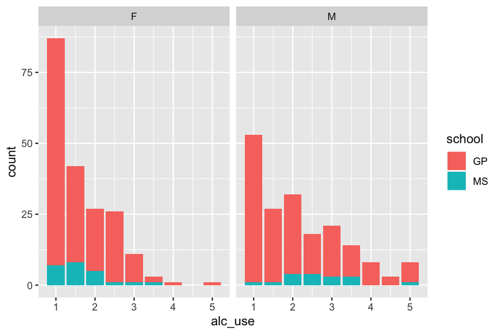

```r
plot1 <- ggplot(data = alc, aes(x=alc_use, fill=school))
plot1 + geom_bar() +
  facet_wrap("sex")
```

*Here we can see that school “GP” shows higher average counts for alcohol use compared to school “MS”. In addition, the female participants have higher counts of very low or low average alcohol consumption compared to males.*

Let’s see whether this changes for high_use

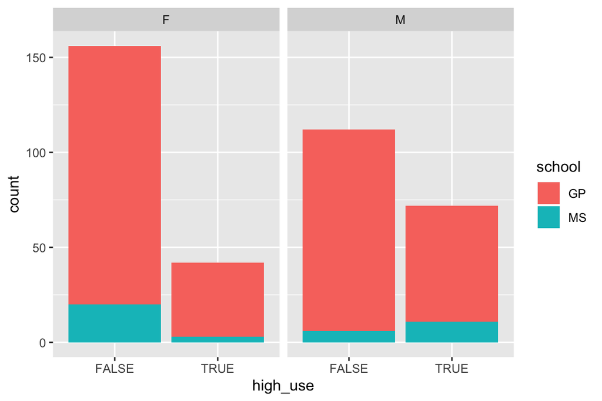

```r
plot2 <- ggplot(data = alc, aes(x=high_use, fill=school))
plot2 + geom_bar() +
  facet_wrap("sex")
```

*Also higher counts for high_alcohol consumption in school “GP” and male students. This confirms our hypothesis that male students consume more alcohol and that students in different schools may have different drinking culture and attitude towards drinking alcohol.*

Let’s see what is the relationship with absences, high_alc usage and sex.

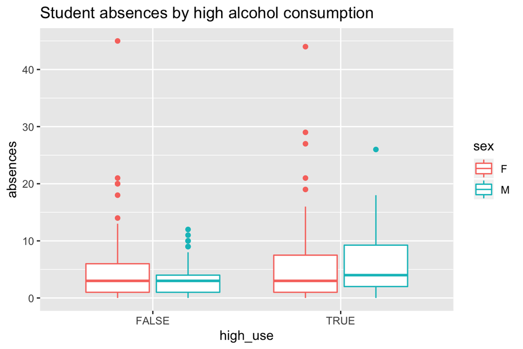

```r
# plot1 explores the relationship of high_use and absences
plot3 <- ggplot(alc, aes(x = high_use, y = absences, col = sex))

# define the plot as a boxplot and draw it
plot3 + geom_boxplot() + ylab("absences") + ggtitle("Student absences by high alcohol consumption")
```

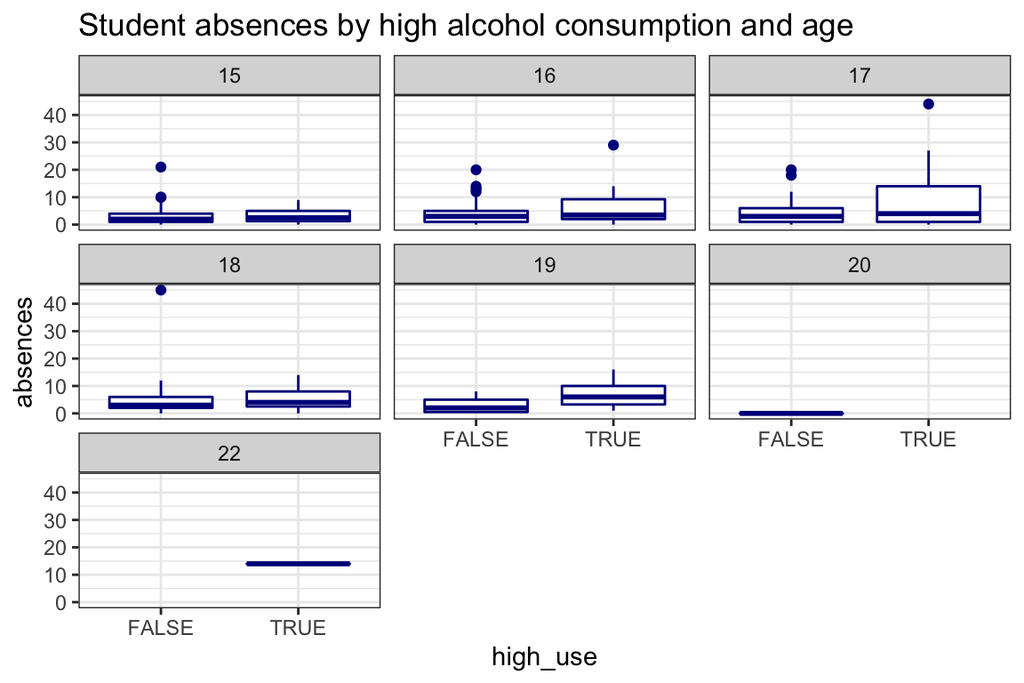

```r
# plot1 explores the relationship of high_use and absences with  variable age
plot4 <- ggplot(alc, aes(x = high_use, y = absences))

# define the plot as a boxplot and draw it
plot4 + geom_boxplot(color="darkblue") + ylab("absences") + facet_wrap("age") + ggtitle("Student absences by high alcohol consumption and age") + theme_bw()
```

*Here we can see that high alcohol consumption is most common for 17 year old students and that they increase the absences.*

### Logistic regression

Let’s explore how high use of alcohol is linked to explanatory variables and use logistic regression

```r
#We can now explore the relationship between four variables and high alcohol consumption with logistic regression
model1 <- glm(high_use ~ school+absences+sex+age, data = alc, family = "binomial")

#Let's study the summary of our fitted model
summary(model1)
```

```
##
## Call:
## glm(formula = high_use ~ school + absences + sex + age, family = "binomial",
##     data = alc)
##
## Deviance Residuals:
##     Min       1Q   Median       3Q      Max
## -2.3081  -0.8357  -0.6384   1.0811   2.1077
##
## Coefficients:
##             Estimate Std. Error z value Pr(>|z|)
## (Intercept) -4.29534    1.79304  -2.396   0.0166 *
## schoolMS     0.30068    0.39803   0.755   0.4500
## absences     0.09467    0.02342   4.042 5.31e-05 ***
## sexM         0.99332    0.24134   4.116 3.86e-05 ***
## age          0.14593    0.10850   1.345   0.1786
## ---
## Signif. codes:  0 '***' 0.001 '**' 0.01 '*' 0.05 '.' 0.1 ' ' 1
##
## (Dispersion parameter for binomial family taken to be 1)
##
##     Null deviance: 465.68  on 381  degrees of freedom
## Residual deviance: 426.48  on 377  degrees of freedom
## AIC: 436.48
##
## Number of Fisher Scoring iterations: 4
```

*Here we can see that age and school are not statistically significant for high_use of alcohol despite our previous interpretation through visualization.* *However, we have factor variables here for school and sex and they are demonstrated in the intercept. Let’s explore the model without school variable.*

```r
#Let's re-fit our model, add -1 to exclude interception and show coefficient estimate values straight
model2 <- glm(high_use ~ sex+age+absences, data = alc, family = "binomial")

#Let's study the summary of our fitted model
summary(model2)
```

```
##
## Call:
## glm(formula = high_use ~ sex + age + absences, family = "binomial",
##     data = alc)
##
## Deviance Residuals:
##     Min       1Q   Median       3Q      Max
## -2.3002  -0.8428  -0.6386   1.0781   2.1068
##
## Coefficients:
##             Estimate Std. Error z value Pr(>|z|)
## (Intercept) -4.73160    1.69730  -2.788  0.00531 **
## sexM         0.98440    0.24074   4.089 4.33e-05 ***
## age          0.17516    0.10125   1.730  0.08365 .
## absences     0.09223    0.02314   3.986 6.71e-05 ***
## ---
## Signif. codes:  0 '***' 0.001 '**' 0.01 '*' 0.05 '.' 0.1 ' ' 1
##
## (Dispersion parameter for binomial family taken to be 1)
##
##     Null deviance: 465.68  on 381  degrees of freedom
## Residual deviance: 427.04  on 378  degrees of freedom
## AIC: 435.04
##
## Number of Fisher Scoring iterations: 4
```

```r
#Let's study the coefficients of our model
coef(model2)
```

```
## (Intercept)        sexM         age    absences
## -4.73159988  0.98439673  0.17515570  0.09223477
```

```r
#Next we can explore the coefficients and their confidence intervals as odd ratios
# We can compute odds ratios (oddrat)
oddrat <- coef(model2) %>% exp

# compute confidence intervals (confin)
confin <- confint(model2) %>% exp

#Npw we can print out our model's coefficients oddratios with their confidence intervals and join them
cbind(oddrat, confin)
```

```
##                  oddrat        2.5 %    97.5 %
## (Intercept) 0.008812361 0.0002990615 0.2356076
## sexM        2.676196933 1.6793970873 4.3232945
## age         1.191431709 0.9782468520 1.4562441
## absences    1.096622249 1.0500945691 1.1499088
```

*Odd ratio describes the ratio of successes to failures. Here we can see that odds ratio for all explanatory variables is higher than 1 for all explanatory variables. This means that e.g. male students have 2.7 times probability to use high levels of alcohol than female students. Absences are likely to increase odds for high alcohol consumption.*

### Predictions

*Absences and sex were statistically significant as explanatory variables. We can now re-fit our model with these variables and explore the predictions.*

```r
# re-fit the model with statistically significant variables
model3 <- glm(high_use ~ absences + sex, data = alc, family = "binomial")

# predict() the probability of high_use
probabilities <- predict(model3, type = "response")

# add the predicted probabilities to 'alc'
alc <- mutate(alc, probability = probabilities)

# use the probabilities to make a prediction of high_use
alc <- mutate(alc, prediction = probabilities>0.5)


# see the last ten original classes, predicted probabilities, and class predictions
select(alc, absences, sex, high_use, probability, prediction) %>%  tail(10)
```

```
##     absences sex high_use probability prediction
## 373        0   M    FALSE   0.2976656      FALSE
## 374        7   M     TRUE   0.4545495      FALSE
## 375        1   F    FALSE   0.1493808      FALSE
## 376        6   F    FALSE   0.2215747      FALSE
## 377        2   F    FALSE   0.1620742      FALSE
## 378        2   F    FALSE   0.1620742      FALSE
## 379        2   F    FALSE   0.1620742      FALSE
## 380        3   F    FALSE   0.1756235      FALSE
## 381        4   M     TRUE   0.3841248      FALSE
## 382        2   M     TRUE   0.3395595      FALSE
```

*Here we can see that all our predictions remain false and true cases of high_use are not predicted correctly. Let’s further explore this visually.*

```r
# tabulate the target variable versus the predictions
table(high_use = alc$high_use, prediction = alc$prediction)
```

```
##         prediction
## high_use FALSE TRUE
##    FALSE   258   10
##    TRUE     88   26
```

*There were 88 false predictions of actual high_use and 26 accurate predictions of high_use.*

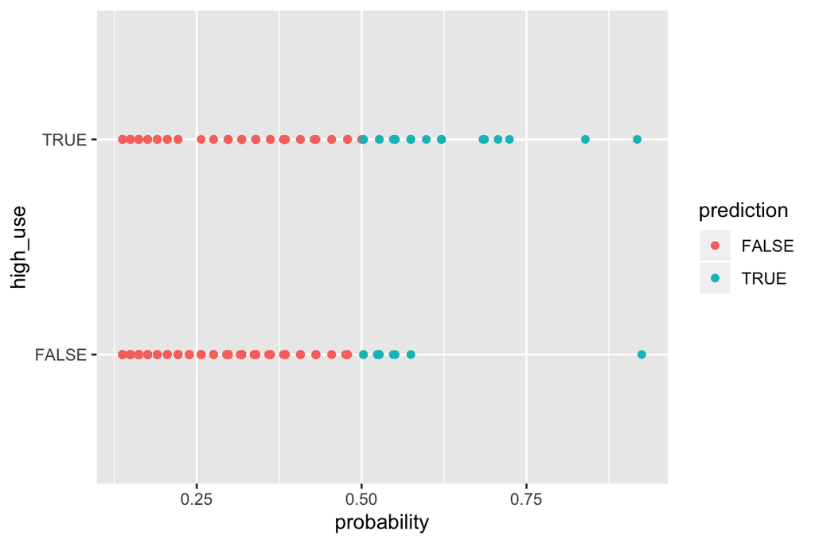

```r
# initialize a plot of 'high_use' versus 'probability' in 'alc'
g <- ggplot(alc, aes(x = probability, y = high_use, col = prediction))

# define the geom as points and draw the plot
g + geom_point()
```

*Here we can see that the rate for true prediction increases, when probability reaches 0.5.*

```r
# tabulate the target variable versus the predictions
table(high_use = alc$high_use, prediction = alc$prediction) %>% prop.table %>% addmargins
```

```
##         prediction
## high_use      FALSE       TRUE        Sum
##    FALSE 0.67539267 0.02617801 0.70157068
##    TRUE  0.23036649 0.06806283 0.29842932
##    Sum   0.90575916 0.09424084 1.00000000
```

##### Bonus: Exploration of cross-validation and wrong predictions

```r
# the logistic regression model m and dataset alc (with predictions) are available

# define a loss function (average prediction error)
loss_func <- function(class, prob) {
  n_wrong <- abs(class - prob) > 0.5
  mean(n_wrong)
}

# compute the average number of wrong predictions in the (training) data


# K-fold cross-validation
library(boot)
crossval1 <- cv.glm(data = alc, cost = loss_func, glmfit = model3, K = 10)

# average number of wrong predictions in the cross validation
crossval1$delta[1]
```

```
## [1] 0.2670157
```

*Since some of the non-significant variables were already excluded from our final model here, we explored the same variables as in DataCamp and model reached around the same 0.26 error.*

##### Super-Bonus: exploration of different model options and their error rate

```r
#Let's explore our previous models model 1 and model 2.
# K-fold cross-validation
#model 1
crossval2 <- cv.glm(data = alc, cost = loss_func, glmfit = model1, K = 10)

# average number of wrong predictions in the cross validation
crossval2$delta[1]
```

```
## [1] 0.2434555
```

```r
# K-fold cross-validation
#model 2
crossval3 <- cv.glm(data = alc, cost = loss_func, glmfit = model2, K = 10)

# average number of wrong predictions in the cross validation
crossval3$delta[1]
```

```
## [1] 0.2486911
```

```r
#############
#And let's try a new test model to explore other variable options internet, school, age and failures
model4 <- glm(high_use ~ internet+school+age+failures, data = alc, family = "binomial")

# K-fold cross-validation
#model 4
crossval4 <- cv.glm(data = alc, cost = loss_func, glmfit = model4, K = 10)

# average number of wrong predictions in the cross validation
crossval4$delta[1]
```

```
## [1] 0.3062827
```

```r
#Let's remove some of the variables one by one to see the effect on predictiosn
model5 <- glm(high_use ~ internet+age+failures, data = alc, family = "binomial")

# K-fold cross-validation
#model 4
crossval5 <- cv.glm(data = alc, cost = loss_func, glmfit = model4, K = 10)

# average number of wrong predictions in the cross validation
crossval5$delta[1]
```

```
## [1] 0.3036649
```

```r
#And let's remove more variables:
model6 <- glm(high_use ~ internet+failures, data = alc, family = "binomial")

# K-fold cross-validation
#model 4
crossval6 <- cv.glm(data = alc, cost = loss_func, glmfit = model4, K = 10)

# average number of wrong predictions in the cross validation
crossval6$delta[1]
```

```
## [1] 0.3010471
```

```r
#And let's try a new model to explore options:
model7 <- glm(high_use ~ internet, data = alc, family = "binomial")

# K-fold cross-validation
#model 4
crossval7 <- cv.glm(data = alc, cost = loss_func, glmfit = model4, K = 10)

# average number of wrong predictions in the cross validation
crossval7$delta[1]
```

```
## [1] 0.2984293
```

```r
#And let's try a new model to explore options:
model7 <- glm(high_use ~ failures, data = alc, family = "binomial")

# K-fold cross-validation
#model 4
crossval7 <- cv.glm(data = alc, cost = loss_func, glmfit = model4, K = 10)

# average number of wrong predictions in the cross validation
crossval7$delta[1]
```

```
## [1] 0.3141361
```